# Part 2 Ambient WC

Frank

2022-07-01

# Introduction

These are codes to analyze and explore patterns in part 2 ambient water chemistry data.

## Import data

```r
library(readxl)
partb_wc <- read_excel("F:/One Drive - Towson U/Thesis stuff/Data/Water chemistry data/Part b WC data/Ambient WC data.xlsx",
    sheet = "Combined")
```

# Range of data

First, let’s summarize the data.

```r
library(dplyr)
partb_wc %>% summary()
```

```
##       Year          Site              Temp (C)        SC (mS/cm)
##  Min.   :2010   Length:31          Min.   : 5.620   Min.   :256.0
##  1st Qu.:2012   Class :character   1st Qu.: 8.405   1st Qu.:346.0
##  Median :2015   Mode  :character   Median :11.210   Median :455.0
##  Mean   :2015                      Mean   :11.571   Mean   :465.3
##  3rd Qu.:2018                      3rd Qu.:14.425   3rd Qu.:558.0
##  Max.   :2019                      Max.   :17.210   Max.   :823.0
##                                                     NA's   :2
##    TSS (ppm)        DO (ppm)         DO (%)            pH
##  Min.   :142.0   Min.   : 7.33   Min.   : 75.5   Min.   :6.680
##  1st Qu.:216.8   1st Qu.:10.54   1st Qu.: 98.9   1st Qu.:7.645
##  Median :314.5   Median :11.44   Median :104.9   Median :7.920
##  Mean   :311.8   Mean   :11.32   Mean   :104.2   Mean   :8.126
##  3rd Qu.:385.2   3rd Qu.:12.22   3rd Qu.:111.5   3rd Qu.:8.495
##  Max.   :535.0   Max.   :13.21   Max.   :120.2   Max.   :9.800
##  NA's   :7       NA's   :4       NA's   :4
##  Salinity (ppt)
##  Min.   :0.0100
##  1st Qu.:0.1475
##  Median :0.2200
##  Mean   :0.2200
##  3rd Qu.:0.2500
##  Max.   :0.4100
##  NA's   :1
```

# Investigate the relationship between pH and %Do

The relationship between %Do and pH is expected to be positive. As more photosynthesis happens in stream, more CO2 is pumped out, which then leads to higher %Do and higher pH. Let’s investigate to see if the relationship holds.

```r
library(dplyr)
ph_do_clean <- as.data.frame(partb_wc) %>%
  rename(c(Temp=`Temp (C)`, SC = `SC (mS/cm)`, TSS = `TSS (ppm)`,
          DO_ppm = `DO (ppm)`, DO_p =  `DO (%)`, Sal =  `Salinity (ppt)`)) %>%
  filter(!is.na(DO_p)) # (1) rename columns; (2) filter NA data from DO column;

cor.test(ph_do_clean$pH,ph_do_clean$DO_p, method = "pearson") #correlational test between pH and DO using Pearson cor
```

```
##
##  Pearson's product-moment correlation
##
## data:  ph_do_clean$pH and ph_do_clean$DO_p
## t = 0.050337, df = 25, p-value = 0.9603
## alternative hypothesis: true correlation is not equal to 0
## 95 percent confidence interval:
##  -0.3713678  0.3885942
## sample estimates:
##        cor
## 0.01006683
```

```r
cor.test(ph_do_clean$pH,ph_do_clean$DO_p, method = "spearman") #correlational test between pH and DO using Spearman cor
```

```
##
##  Spearman's rank correlation rho
##
## data:  ph_do_clean$pH and ph_do_clean$DO_p
## S = 3042, p-value = 0.7233
## alternative hypothesis: true rho is not equal to 0
## sample estimates:
##        rho
## 0.07143948
```

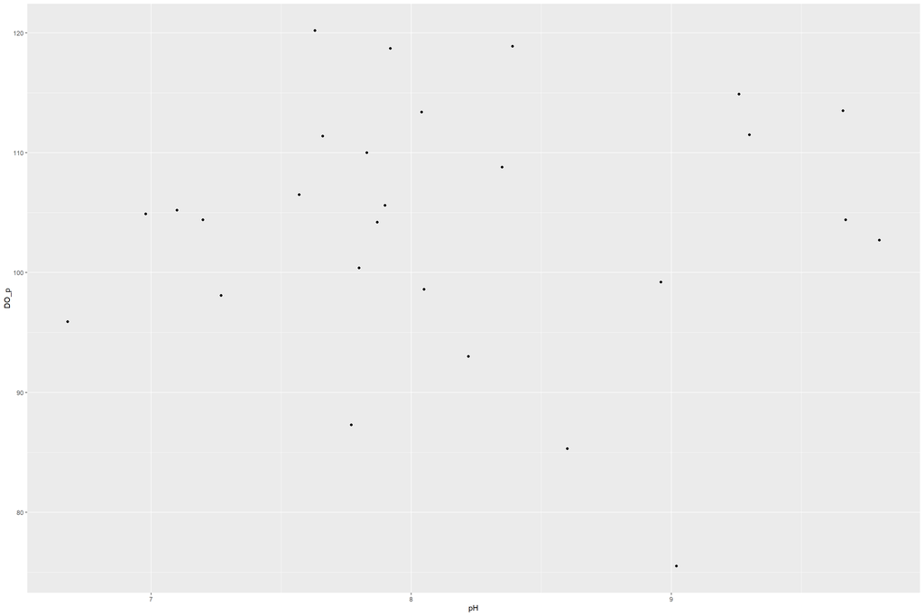

```r
library(ggplot2)
ph_do_clean %>% ggplot(aes(pH, DO_p)) + geom_point()
```

In conclusion, pH and %DO have no correlation with each other in this data set, since there seems to be some extreme values.

# Create a matrix of scatterplots

## Pearson

These codes were used to create a scatterplot matrix (Pearson’s correlation) using the package GGally (Schloerke et al. 2021).

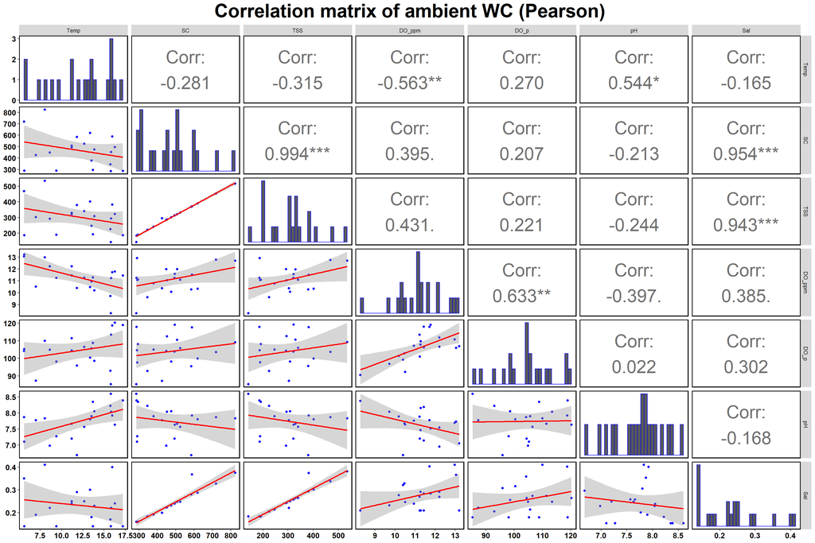

```r
library(dplyr)
library(GGally)

lowerFn <- function(data, mapping, method = "lm", ...) {
  p <- ggplot(data = data, mapping = mapping) +
    geom_point(colour = "blue") +
    geom_smooth(method = method, color = "red", ...)
  p
} #code adopted from WCC - an user on Stack Overflow. Check out his profile here: https://stackoverflow.com/users/1102552/wcc.

wc_clean <- partb_wc %>% rename(c(Temp=`Temp (C)`, SC = `SC (mS/cm)`, TSS = `TSS (ppm)`,
          DO_ppm = `DO (ppm)`, DO_p =  `DO (%)`, Sal =  `Salinity (ppt)`)) %>%
  filter(!is.na(SC) & !is.na(TSS) & !is.na(DO_p))

wc_clean %>%
  ggpairs(columns = c("Temp","SC","TSS","DO_ppm","DO_p","pH","Sal"),
          lower = list(continuous = wrap(lowerFn, method = "lm")),
  diag = list(continuous = wrap("barDiag", colour = "blue")),
  upper = list(continuous = wrap("cor", size = 10))
) +  theme(axis.text.y = element_text(colour = "black", size = 12, face = "bold"),
    axis.text.x = element_text(colour = "black", face = "bold", size = 12),
    legend.text = element_text(size = 12, face ="bold", colour ="black"),
    axis.title.x = element_text(face = "bold", size = 14, colour = "black"),
    legend.title = element_text(size = 14, colour = "black", face = "bold"),
    panel.background = element_blank(), panel.border = element_rect(colour = "black", fill = NA, size = 1.2),
    legend.key=element_blank(),
    plot.title = element_text(color = "black", size = 30, face = "bold", hjust = 0.5)) +
   labs(
    title = "Correlation matrix of ambient WC (Pearson)")
```

## Spearman

Previous codes will be modified to display Spearman correlation. For now, traditional method will be applied. Package *corrr* (Kuhn et al. 2020) will be used to test for significant correlations among variables.

```r
library(corrr)

wc_cor <- wc_clean[,3:ncol(wc_clean)] %>% correlate(use = "pairwise.complete.obs", method = "spearman") %>%
  select(Temp, SC, TSS, DO_ppm, DO_p, pH, Sal) %>% mutate(Variable = c(1,2,3,4,5,6,7), .before = Temp)
wc_cor$Variable <- recode(wc_cor$Variable,
                          "1" = "Temp",
                          "2" = "SC",
                          "3" = "TSS",
                          "4" = "DO_ppm",
                          "5" = "DO_p",
                          "6" = "pH",
                          "7" = "Sal")
wc_cor
```

```
## # A tibble: 7 x 8
##   Variable   Temp     SC    TSS DO_ppm    DO_p      pH    Sal
##   <chr>     <dbl>  <dbl>  <dbl>  <dbl>   <dbl>   <dbl>  <dbl>
## 1 Temp     NA     -0.221 -0.245 -0.410  0.374   0.608  -0.176
## 2 SC       -0.221 NA      0.995  0.269  0.205  -0.295   0.987
## 3 TSS      -0.245  0.995 NA      0.250  0.170  -0.293   0.982
## 4 DO_ppm   -0.410  0.269  0.250 NA      0.605  -0.368   0.262
## 5 DO_p      0.374  0.205  0.170  0.605 NA       0.0767  0.209
## 6 pH        0.608 -0.295 -0.293 -0.368  0.0767 NA      -0.272
## 7 Sal      -0.176  0.987  0.982  0.262  0.209  -0.272  NA
```

Another way of doing this, but will also give you a correlation and p-value matrix. Package *rstatix* will be used (Kassambara 2021.)

```r
library(rstatix)
options(digits = 3)   # report 3 significant digits
wc_clean[,3:ncol(wc_clean)] %>% cor_mat(Temp, SC, TSS, DO_ppm, DO_p, pH, Sal, method = "spearman") %>% cor_get_pval()
```

```
## # A tibble: 7 x 8
##   rowname       Temp       SC      TSS    DO_ppm       DO_p         pH      Sal
##   <chr>        <dbl>    <dbl>    <dbl>     <dbl>      <dbl>      <dbl>    <dbl>
## 1 Temp    0.00000598 3.47e- 1 2.96e- 1 7.26e-  2 0.105      0.00535    4.58e- 1
## 2 SC      0.347      5.98e- 6 6.13e- 6 2.51e-  1 0.385      0.207      1.13e-15
## 3 TSS     0.296      6.13e- 6 5.98e- 6 2.88e-  1 0.472      0.209      1.59e-14
## 4 DO_ppm  0.0726     2.51e- 1 2.88e- 1 1.25e-139 0.00473    0.111      2.64e- 1
## 5 DO_p    0.105      3.85e- 1 4.72e- 1 4.73e-  3 0.00000598 0.748      3.78e- 1
## 6 pH      0.00535    2.07e- 1 2.09e- 1 1.11e-  1 0.748      0.00000598 2.47e- 1
## 7 Sal     0.458      1.13e-15 1.59e-14 2.64e-  1 0.378      0.247      0
```

# References

1. Barret Schloerke, Di Cook, Joseph Larmarange, Francois Briatte, Moritz Marbach, Edwin Thoen, Amos Elberg and Jason Crowley (2021). GGally: Extension to ‘ggplot2’. R package version 2.1.2. https://CRAN.R-project.org/package=GGally
2. Max Kuhn, Simon Jackson and Jorge Cimentada (2020). corrr: Correlations in R. R package version 0.4.3. https://CRAN.R-project.org/package=corrr
3. Alboukadel Kassambara (2021). rstatix: Pipe-Friendly Framework for Basic Statistical Tests. R package version 0.7.0. https://CRAN.R-project.org/package=rstatix